[figure not shown]

## An R package for arranging arrangements

### Repository contents

- **README.md**  
  This readme file.
- **trotter.R**  
  The R code defining the classes and constructors.

### Introduction

The `trotter` package provides the R user access to two classes - `PPV` (Permutations Pseudo-vector) and `CPV` (Combinations Pseudo-vector) - that simplify the process of working with permutations and combinations of objects stored in a vector.

Instances of `PPV` and `CPV` are compatable with the functions:

- `length`
- `[`

Instances of `PPV` and `CPV` are created using the constructors `ppv` and `cpv` respectively. Both constructors have two arguments:

- `k` the number of objects to take.
- `items` a vector containing the available objects.

We can think about instances of `PPV` and `CPV` as vectors containing all the possible permutations and combinations respectively with the given parameters. (They are pseudo-vectors because they don’t actually store the arrangements in memory and can thus be used to “store” very large numbers of arrangements.)

### Example: basic use

```r
library(trotter)
a.to.j <- letters[1:10]

perms.5 <- ppv(k = 5, items = a.to.j)
combs.5 <- cpv(k = 5, items = a.to.j)

# How many 5-permutations are there of the first 10 letters?
length(perms.5)
```

```
## [1] 30240
```

```r
# Let's inspect a few of them...
perms.5[1]
```

```
## [1] "a" "b" "c" "d" "e"
```

```r
perms.5[10000]
```

```
## [1] "a" "f" "c" "g" "j"
```

```r
perms.5[30240]
```

```
## [1] "g" "f" "h" "i" "j"
```

```r
# How many 5-combinations?
length(combs.5)
```

```
## [1] 252
```

```r
# Let's inspect a few of them...
combs.5[1]
```

```
## [1] "a" "b" "c" "d" "e"
```

```r
combs.5[100]
```

```
## [1] "a" "d" "e" "h" "j"
```

```r
combs.5[252]
```

```
## [1] "f" "g" "h" "i" "j"
```

```r
# The pseudo-vectors can "store" a large number of arrangements
# while being very easy on the memory and evaluation time...
perms.10.of.15 <- ppv(10, letters[1:15])
perms.10.of.15
```

```
## Instance of class PPV
##  Pseudo-vector containing 10897286400 10-permutations
##  of items taken from the list:
## [a, b, c, d, e, f, g, h, i, j, k, l, m, n, o]
```

```r
perms.10.of.15[1]
```

```
##  [1] "a" "b" "c" "d" "e" "f" "g" "h" "i" "j"
```

```r
perms.10.of.15[10000000000L]
```

```
##  [1] "m" "k" "j" "d" "e" "g" "f" "i" "c" "n"
```

```r
perms.10.of.15[10897286400L]
```

```
##  [1] "g" "f" "h" "i" "j" "k" "l" "m" "n" "o"
```

### Example: application

The following example illustrates an application in which we are interested in finding which 3-combination from a set of predictors produces a linear model with a greatest $R^2$ value.

```r
# Load and inspect the mtcars data set
data(mtcars)
head(mtcars)
```

```
##                    mpg cyl disp  hp drat    wt  qsec vs am gear carb
## Mazda RX4         21.0   6  160 110 3.90 2.620 16.46  0  1    4    4
## Mazda RX4 Wag     21.0   6  160 110 3.90 2.875 17.02  0  1    4    4
## Datsun 710        22.8   4  108  93 3.85 2.320 18.61  1  1    4    1
## Hornet 4 Drive    21.4   6  258 110 3.08 3.215 19.44  1  0    3    1
## Hornet Sportabout 18.7   8  360 175 3.15 3.440 17.02  0  0    3    2
## Valiant           18.1   6  225 105 2.76 3.460 20.22  1  0    3    1
```

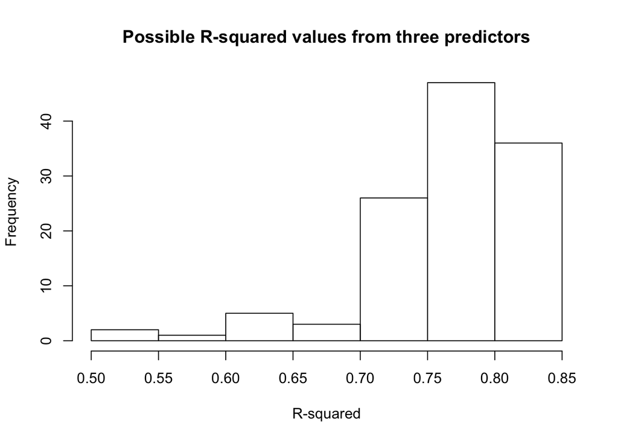

```r
# Create a vector containing the variables we wish to treat as predictors
predictors <- names(mtcars)[2:11]

# Load the trotter library
library(trotter)

# Create pseudo-vector of 3-combinations of predictors
pred3c <- cpv(3, predictors)

# A helper-function that returns a linear model from a
# combination of variables
model.from.combo <- function(combo) lm(
  as.formula(
    sprintf(
      "mpg ~ %s",
      paste(
        combo,
        collapse = "+"
      )
    )
  ),
  data = mtcars
)

# Create an array containing all the possible R-squared values
r.squared.values <- sapply(
  1:length(pred3c),
  function(i) summary(model.from.combo(pred3c[i]))$r.squared
)

# Examine the distribution of R-squared values possible in a
# linear fitting using three predictors

hist(
  r.squared.values,
  main = "Possible R-squared values from three predictors",
  xlab = "R-squared"
)
```

```r
# Retrieve the model that produced the greatest R-squared value
index <- which.max(r.squared.values)
best.three.predictors <- pred3c[index]
best.three.predictors
```

```
## [1] "wt"   "qsec" "am"
```

```r
best.three.model <- model.from.combo(best.three.predictors)
summary(best.three.model)
```

```
##
## Call:
## lm(formula = as.formula(sprintf("mpg ~ %s", paste(combo, collapse = "+"))),
##     data = mtcars)
##
## Residuals:
##    Min     1Q Median     3Q    Max
## -3.481 -1.556 -0.726  1.411  4.661
##
## Coefficients:
##             Estimate Std. Error t value Pr(>|t|)
## (Intercept)    9.618      6.960    1.38  0.17792
## wt            -3.917      0.711   -5.51    7e-06 ***
## qsec           1.226      0.289    4.25  0.00022 ***
## am             2.936      1.411    2.08  0.04672 *
## ---
## Signif. codes:  0 '***' 0.001 '**' 0.01 '*' 0.05 '.' 0.1 ' ' 1
##
## Residual standard error: 2.46 on 28 degrees of freedom
## Multiple R-squared:  0.85,   Adjusted R-squared:  0.834
## F-statistic: 52.7 on 3 and 28 DF,  p-value: 1.21e-11
```

### Some details

The permutations “contained” in a `PPV` instance can be thought of as having an arrangement similar (but not necessarily the same) to that produced by the [Steinhaus-Johnson-Trotter](http://en.wikipedia.org/wiki/Steinhaus%E2%80%93Johnson%E2%80%93Trotter_algorithm) algorithm. The combinations “contained” in a `CPV` instance are arranged in an order corresponding to the order of object appearance in the vector `items`; that is, all the combinations containing the first object are followed by all the combinations containing the second object but not the first, which are followed by all the combinations containing the third object but neither the first or second, etc.